# Getting Started with mStats package

Myo Minn Oo

13 February, 2019

## Why this package?

I am one of people who do not want to type similar command lines repeated. I also need some flexible tools to tailor my need. Some packages I like and inspire include **epicalc** (by *Aj. Virasakdi*) and **tidyverse** (by *Hadley Wickham*). There are some more packages, but I am not going to list here. I use many useful functions from these packages in my daily data management and analysis but I need something of my own style to make my work more efficient and productive.

## Getting Started

To use this package, you need ‘ggplot2’ package installed in your R softare.

```r
install.packages("ggplot2", dependencies = TRUE)
```

There are two ways to install mStats package.

#### 1. Install directly from [github](https://github.com/myominnoo/mStats)

mStats is regularly updated on [my website](https://myominnoo.github.io/pages/software.html).

```r
install.packages("devtools") # installing devtools package
devtools::install_github("myominnoo/mStats")
```

Load mStats package.

```r
library(mStats)
```

#### 2. Install from tar.gz file

1. Go to [my website](https://myominnoo.github.io/pages/software.html).
2. Download the latest version at the bottom of the page.
3. Open ‘R Studio’.
4. Go to **Package** Tab on the right bottom.
5. Click **Install** and choose **Package Archive File (.tgz; .tar.gz.)** under **Install from**. Then Click **OK**.

## isum()

> A Quick Simple Summary

One thing I would like to have in data exploration is a quick and simple way to summarize my data. It can be either an object (variable), or a data set. One of the distinct feature about this function is that I develop this in a way to minimize the number of different command lines for different purpose of summary statistics. For example, summary function in base R provide count for factor type and six number summary for continuous data. What I want is a bit more different.  
See help page for specifying arguments and more examples.

```r
?isum
```

#### Summary of a data frame

let’s use **infert** data from R. It is a data frame. isum() generate summary outputs for each variable based on its type.

> Basically, it provides number summary for numeric data and tabulation for factor, character and even logical data.

```r
str(infert)
```

```
## 'data.frame':    248 obs. of  8 variables:
##  $ education     : Factor w/ 3 levels "0-5yrs","6-11yrs",..: 1 1 1 1 2 2 2 2 2 2 ...
##  $ age           : num  26 42 39 34 35 36 23 32 21 28 ...
##  $ parity        : num  6 1 6 4 3 4 1 2 1 2 ...
##  $ induced       : num  1 1 2 2 1 2 0 0 0 0 ...
##  $ case          : num  1 1 1 1 1 1 1 1 1 1 ...
##  $ spontaneous   : num  2 0 0 0 1 1 0 0 1 0 ...
##  $ stratum       : int  1 2 3 4 5 6 7 8 9 10 ...
##  $ pooled.stratum: num  3 1 4 2 32 36 6 22 5 19 ...
```

```r
isum(infert)
```

```
## $Number.Summary
##                Obs. NA. Mean   SD Median Q1   Q3 Min Max
## age             248   0 31.5  5.3     31 28 35.2  21  44
## parity          248   0  2.1  1.3      2  1  3.0   1   6
## induced         248   0  0.6  0.7      0  0  1.0   0   2
## case            248   0  0.3  0.5      0  0  1.0   0   1
## spontaneous     248   0  0.6  0.7      0  0  1.0   0   2
## stratum         248   0 41.9 24.0     42 21 62.2   1  83
## pooled.stratum  248   0 33.6 17.3     36 19 48.2   1  63
##
## $Freq.Summary
## $Freq.Summary$education
##
## education   n (col%) (cum.col%)
##   0-5yrs   12    4.8        4.8
##   6-11yrs 120   48.4       53.2
##   12+ yrs 116   46.8      100.0
##   Total   248  100.0      100.0
```

#### Summary of numeric data

Here are examples of isumming single numeric data. Outputs include a number summary table and a box plot with normality test.

> Single Numeric data

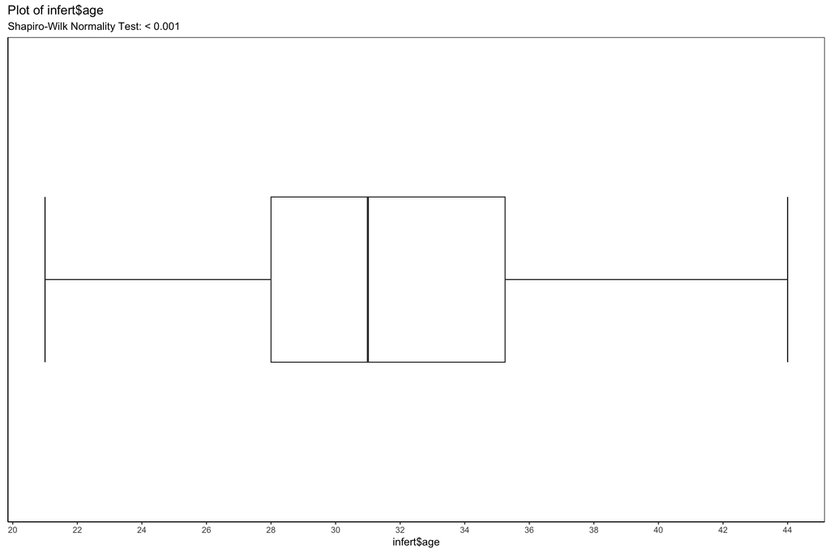

```
##            Obs. NA. Mean  SD Median Q1   Q3 Min Max
## infert$age  248   0 31.5 5.3     31 28 35.2  21  44
```

```r
# by default it displays boxplot
isum(x = infert$age)
```

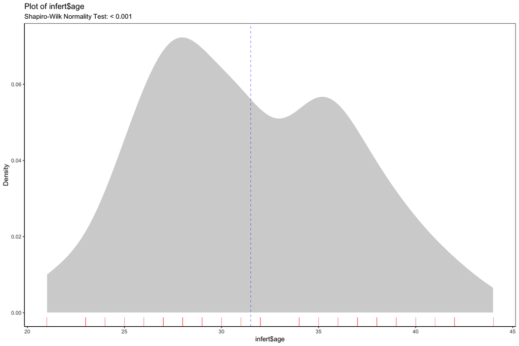

```
##            Obs. NA. Mean  SD Median Q1   Q3 Min Max
## infert$age  248   0 31.5 5.3     31 28 35.2  21  44
```

```r
# change to Kernel Density Plot
isum(x = infert$age, boxplot = FALSE)
```

> You can summarize without attaching the data.

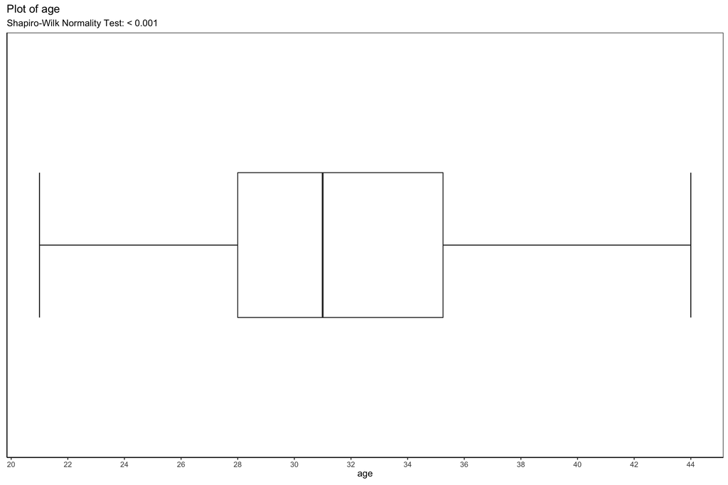

```
##     Obs. NA. Mean  SD Median Q1   Q3 Min Max
## age  248   0 31.5 5.3     31 28 35.2  21  44
```

```r
# summarizing without attaching the data
isum(x = age, data = infert)
```

> Numeric Vs Numeric

Outputs include a number summary table and a scatterplot with correlation test.

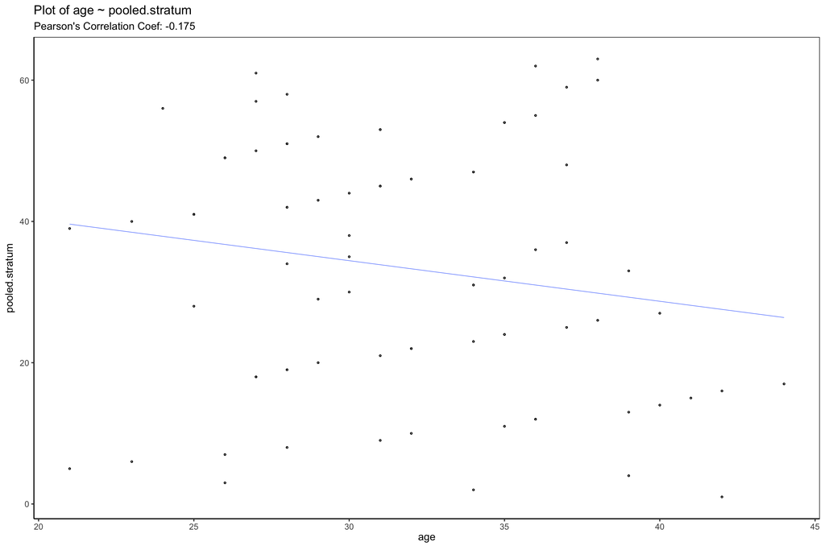

```
##                Obs. NA. Mean   SD Median Q1   Q3 Min Max Pearson's Corr
## age             248   0 31.5  5.3     31 28 35.2  21  44         -0.175
## pooled.stratum  248   0 33.6 17.3     36 19 48.2   1  63
```

```r
# by default it displays boxplot
isum(x = age, y = pooled.stratum, data = infert)
```

> Numeric Vs Factor

Outputs include a number summary table stratified by factor and boxplot comparison with mean difference test (t test OR ANOVA based on levels of categories).

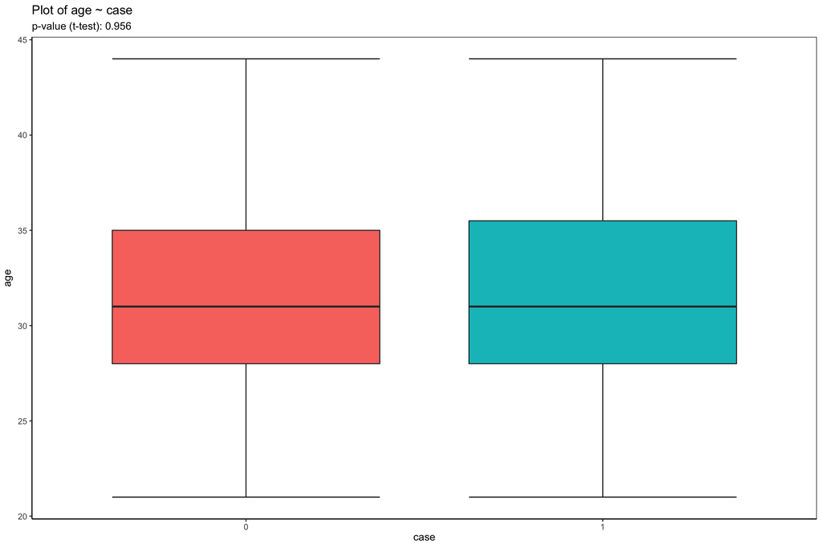

```
##     Obs. NA. Mean  SD Median Q1   Q3 Min Max  SE CI.Lwr CI.Upr t value p.value
## age  248   0 31.5 5.3     31 28 35.2  21  44 0.9   29.7   92.3    -0.1   0.956
## _      _   _    _   _      _  _    _   _   _   _      _      _
## 0    165   0 31.5 5.3     31 28   35  21  44 0.9   29.7   92.3
## 1     83   0 31.5 5.3     31 28 35.5  21  44 0.9   29.7   92.3
```

```r
infert$case <- factor(infert$case)
isum(x = age, y = case, data = infert)
```

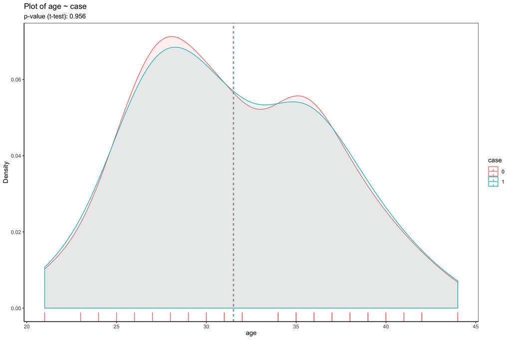

```
##     Obs. NA. Mean  SD Median Q1   Q3 Min Max  SE CI.Lwr CI.Upr t value p.value
## age  248   0 31.5 5.3     31 28 35.2  21  44 0.9   29.7   92.3    -0.1   0.956
## _      _   _    _   _      _  _    _   _   _   _      _      _
## 0    165   0 31.5 5.3     31 28   35  21  44 0.9   29.7   92.3
## 1     83   0 31.5 5.3     31 28 35.5  21  44 0.9   29.7   92.3
```

```r
# change to Kernel Density plot
isum(x = age, y = case, data = infert, boxplot = FALSE)
```

> Numeric Vs Factor, Stratified by Factor

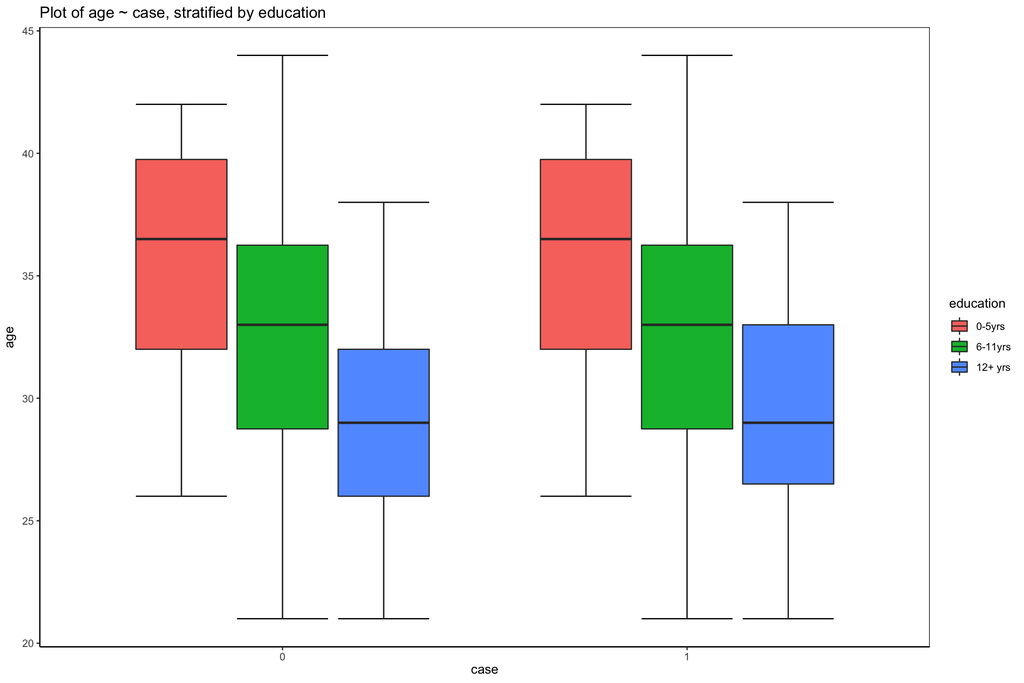

```
## $`0-5yrs`
##     Obs. NA. Mean  SD Median Q1   Q3 Min Max  SE CI.Lwr CI.Upr t value p.value
## age   12   0 35.2 6.3   36.5 32 39.8  26  42 1.1     33  106.7       0       1
## _      _   _    _   _      _  _    _   _   _   _      _      _
## 0      8   0 35.2 6.5   36.5 32 39.8  26  42 1.1     33  106.7
## 1      4   0 35.2   7   36.5 32 39.8  26  42 1.2   32.8  106.7
##
## $`6-11yrs`
##     Obs. NA. Mean  SD Median   Q1   Q3 Min Max  SE CI.Lwr CI.Upr t value p.value
## age  120   0 32.9 5.4     33 28.8 36.2  21  44 0.9   31.1   97.6       0       1
## _      _   _    _   _      _    _    _   _   _   _      _      _
## 0     80   0 32.9 5.4     33 28.8 36.2  21  44 0.9   31.1   97.6
## 1     40   0 32.9 5.4     33 28.8 36.2  21  44 0.9   31.1   97.6
##
## $`12+ yrs`
##     Obs. NA. Mean  SD Median   Q1   Q3 Min Max  SE CI.Lwr CI.Upr t value p.value
## age  116   0 29.7 4.4     29   26 32.5  21  38 0.8   28.1   86.5    -0.1   0.903
## _      _   _    _   _      _    _    _   _   _   _      _      _
## 0     77   0 29.7 4.4     29   26   32  21  38 0.8   28.1   86.5
## 1     39   0 29.8 4.5     29 26.5   33  21  38 0.8   28.2   86.6
```

```r
isum(x = age, y = case, by = education, data = infert)
```

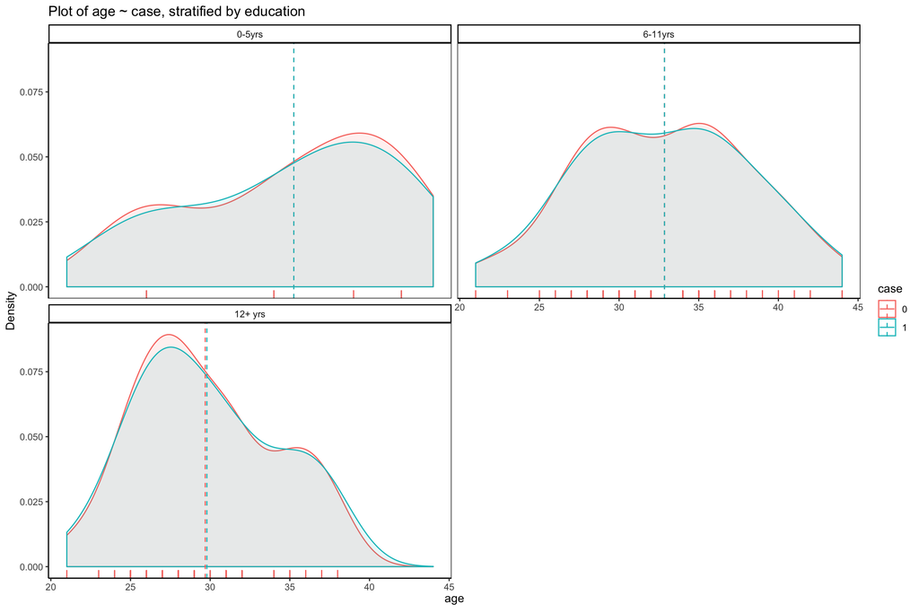

```
## $`0-5yrs`
##     Obs. NA. Mean  SD Median Q1   Q3 Min Max  SE CI.Lwr CI.Upr t value p.value
## age   12   0 35.2 6.3   36.5 32 39.8  26  42 1.1     33  106.7       0       1
## _      _   _    _   _      _  _    _   _   _   _      _      _
## 0      8   0 35.2 6.5   36.5 32 39.8  26  42 1.1     33  106.7
## 1      4   0 35.2   7   36.5 32 39.8  26  42 1.2   32.8  106.7
##
## $`6-11yrs`
##     Obs. NA. Mean  SD Median   Q1   Q3 Min Max  SE CI.Lwr CI.Upr t value p.value
## age  120   0 32.9 5.4     33 28.8 36.2  21  44 0.9   31.1   97.6       0       1
## _      _   _    _   _      _    _    _   _   _   _      _      _
## 0     80   0 32.9 5.4     33 28.8 36.2  21  44 0.9   31.1   97.6
## 1     40   0 32.9 5.4     33 28.8 36.2  21  44 0.9   31.1   97.6
##
## $`12+ yrs`
##     Obs. NA. Mean  SD Median   Q1   Q3 Min Max  SE CI.Lwr CI.Upr t value p.value
## age  116   0 29.7 4.4     29   26 32.5  21  38 0.8   28.1   86.5    -0.1   0.903
## _      _   _    _   _      _    _    _   _   _   _      _      _
## 0     77   0 29.7 4.4     29   26   32  21  38 0.8   28.1   86.5
## 1     39   0 29.8 4.5     29 26.5   33  21  38 0.8   28.2   86.6
```

```r
# change to Kernel Density plot
isum(x = age, y = case, by = education, data = infert, boxplot = FALSE)
```